# Analysis of tuberculosis cases

Paweł Kaciczak

31 10 2020

# Introducing

This document tries to analyze cases of tuberculosis on the world by country, years and sex.

## What is tuberculosis?

Tuberculosis is an infection disease usually caused by *Mycobacterium tuberculosis* (MTB) bacteria. The disease is spread from one person to anther through air when people with tuberculosis cough, spit, speak or sneeze.

## Signs & symptoms

Tuberculosis may infect any part of the body, but mostly it infects lungs - then it is known as pulmonary tuberculosis. Extrapulmonary tuberculosis occurs when it develops outside of thelungs.

### Pulmonary

When tuberculosis infect the lungs, symptoms may include chest pain prolonged cough with sputum. About 25% of people may not have any symptoms. Occasionally, they may cough up blood in small amounts.

### Extrapulmonary

In 15-20% of active cases, the infection spreads outside the lungs. Extrapulmonary tuberculosis occurs more commonly in people with a weakened immune system and young children. Notable extrapulmonary infection sites include the pleura, the central nervous system, and the bones and joints.

## Prevention

There is one available vaccine from 2011. In the children decreases the risk by 20% and the risk of infection turning int active disease by nearly 60%. It is the most widely used vaccine worldwide, with more than 90% of all children being vaccinated.

## Treatment

Treatment of tuberculosis uses antibiotics to kill the bacteria. Effective treatment is difficult, due to the unusual structure and chemical composition of mycobacterial cell wall, which hiders the entry of drugs and makes many antibiotic ineffective. Active tuberculosis is best treated with combinations of several antibiotics to reduce the risk of the bacteria developing antibiotic resistance. The routine use of *rifabutin* instead of *rifampicin*.

# Analysis

Datas are taken from World Health Organization Global Tuberculosis Report. The dataset was downloaded from github repository (rstudio/EDAWR) Datas about tuberculosis are in variable tb (TuBerculosis). The analysis will be in R. The report will be generated by knitr in RStudio. Below structure od dataset:

| country | year | sex | child | adult | elderly |
| --- | --- | --- | --- | --- | --- |
| Afghanistan | 1995 | female | NA | NA | NA |
| Afghanistan | 1995 | male | NA | NA | NA |
| Afghanistan | 1996 | female | NA | NA | NA |
| Afghanistan | 1996 | male | NA | NA | NA |
| Afghanistan | 1997 | female | 5 | 96 | 1 |
| Afghanistan | 1997 | male | 0 | 26 | 0 |

As we can see, dataset is 6 columns. Each row is one observation. In the first column there is a name of country. In second column there is year in which the observation was made. In the third column there is sex of observation group of people. The column 4 to 6 includes number of cases in three groups of people:

- Child - number of cases reported among people under 14 years old,
- Adult - number of cases reported among people from 15 to 64 years old,
- Elderly - number of cases reported among people over 64 years old.

This dataset is not clear - there is some missing values. In next steps, you should filter these values out.

## Short summary

Below short summary in R about data in dataset.

```r
summary(tb)
```

```
##    country               year          sex                child
##  Length:3800        Min.   :1995   Length:3800        Min.   :    0.0
##  Class :character   1st Qu.:1999   Class :character   1st Qu.:   25.0
##  Mode  :character   Median :2004   Mode  :character   Median :   76.0
##                     Mean   :2004                      Mean   :  493.2
##                     3rd Qu.:2009                      3rd Qu.:  264.5
##                     Max.   :2013                      Max.   :25661.0
##                                                       NA's   :396
##      adult           elderly
##  Min.   :     0   Min.   :     0.0
##  1st Qu.:  1128   1st Qu.:    84.5
##  Median :  2589   Median :   230.0
##  Mean   : 10864   Mean   :  1253.0
##  3rd Qu.:  6706   3rd Qu.:   640.0
##  Max.   :731540   Max.   :125991.0
##  NA's   :413      NA's   :413
```

The observations was made from 1995 to 2013 and include 3800 single observations.

In the datasets are 100 different countries.

## Cleaning data

First step of data cleaning process was to replace *NA* with zeros so that the data could be computed correctly.

```r
non_clean_tb <- tb
tb[is.na(tb)] <- 0

clean_tb <- tb

head(clean_tb)
```

```
## # A tibble: 6 x 6
##   country      year sex    child adult elderly
##   <chr>       <int> <chr>  <int> <int>   <int>
## 1 Afghanistan  1995 female     0     0       0
## 2 Afghanistan  1995 male       0     0       0
## 3 Afghanistan  1996 female     0     0       0
## 4 Afghanistan  1996 male       0     0       0
## 5 Afghanistan  1997 female     5    96       1
## 6 Afghanistan  1997 male       0    26       0
```

## Number of TB cases per sex

First, we need to group our data by sex.

```r
grouped_sex <- select(clean_tb, sex, child, adult, elderly) %>%
                group_by(sex) %>%
                summarise(number=sum(child + adult + elderly), .groups = 'drop')
```

After that, we can create a chart showing number of cases in each sex.

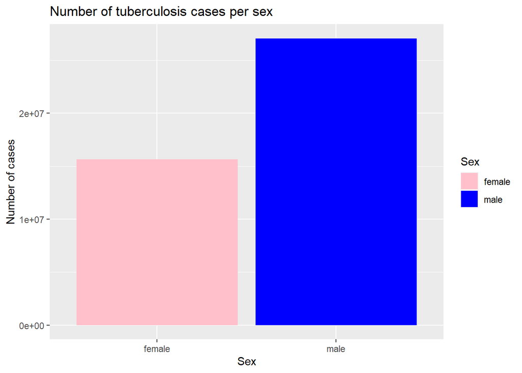

```r
ggplot(grouped_sex, aes(x=sex, y=number, fill=sex)) +
        geom_bar(stat="identity") +
        labs(title="Number of tuberculosis cases per sex",
             fill="Sex",
             x="Sex",
             y="Number of cases") +
        scale_fill_manual(values= c("pink", "blue"))
```

## Number of TB cases per group

At the beginning, we need to summarise cases in each group of observate people.

```r
grouped_people_by_group <- select(clean_tb, year, child, adult, elderly) %>%
          group_by(year) %>%
          summarise(child = sum(child), adult = sum(adult), elderly = sum(elderly), .groups = 'drop')
```

Then, we can create a chart showing number of cases in each observate group of people.

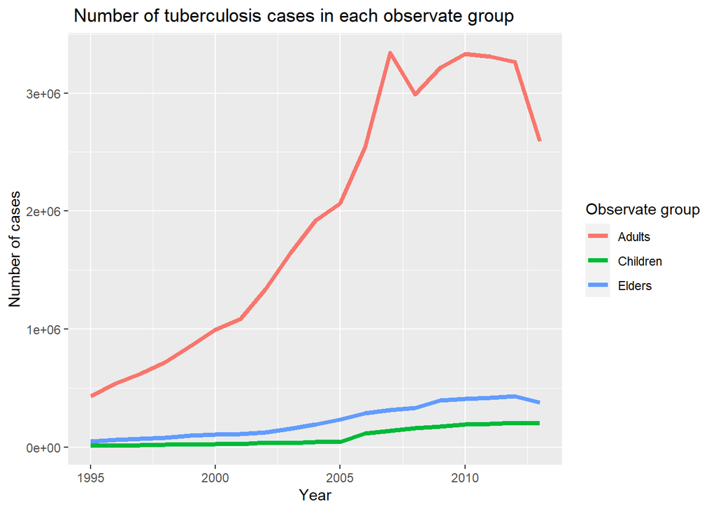

```r
ggplot(grouped_people_by_group, aes(x=year)) +
      geom_line(aes(y=child, color="Children"), size=1.5) +
      geom_line(aes(y=adult, color="Adults"), size=1.5) +
      geom_line(aes(y=elderly, color="Elders"), size=1.5) +
      labs(title = " Number of tuberculosis cases in each observate group",
          x="Year",
          y="Number of cases",
          color="Observate group")
```

We see, the most cases of tuberculosis are in the group of adult people. One of cause of this result may be the range of age of observate people (15 - 64 years old). The greater amount of people on the whole world are in this range so the result is not surprising.

## Number of TB cases per country

In the first step, we need to group data by countries and years.

```r
grouped_country <-  select(clean_tb, country, year, child, adult, elderly) %>%
                            group_by(country, year) %>%
                            summarise(number = sum(child+adult+elderly), .groups = 'drop')

head(grouped_country, 10)
```

```
## # A tibble: 10 x 3
##    country      year number
##    <chr>       <int>  <int>
##  1 Afghanistan  1995      0
##  2 Afghanistan  1996      0
##  3 Afghanistan  1997    128
##  4 Afghanistan  1998   1778
##  5 Afghanistan  1999    745
##  6 Afghanistan  2000   2666
##  7 Afghanistan  2001   4639
##  8 Afghanistan  2002   6509
##  9 Afghanistan  2003   6528
## 10 Afghanistan  2004   8245
```

Now, we need to get names of countries from our data.

```r
countries <- distinct(grouped_country, country)

head(countries, 10)
```

```
## # A tibble: 10 x 1
##    country
##    <chr>
##  1 Afghanistan
##  2 Algeria
##  3 Angola
##  4 Argentina
##  5 Azerbaijan
##  6 Bangladesh
##  7 Belarus
##  8 Benin
##  9 Bolivia (Plurinational State of)
## 10 Botswana
```